# Educational Data Analysis

Osvaldo Martins Quintella Junior

Last edited 30 março 2024

### Exploratory Data Analysis of Censo Escolar

The following code load the necessary packages.

```r
library(tidyverse)
library(ggthemes)
```

The following code read the data from my computer. But I saved all the data on a .RData file. This file is uploaded to github so everyone can download it and check the code by yourself.

```r
read.data <- function(year, file, variables){
  censo.escolar.year <- read_delim(file,
                                 delim = ';',
                                 locale = locale(encoding = 'WINDOWS-1252'),
                                 escape_double = TRUE,
                                 trim_ws = TRUE,
                                 col_select = variables)}

variables <- c('NU_ANO_CENSO', 'NO_REGIAO', 'CO_REGIAO',
                                 'CO_UF', 'NO_MUNICIPIO', 'CO_ENTIDADE',
                                 'TP_DEPENDENCIA', 'TP_LOCALIZACAO', 'TP_CATEGORIA_ESCOLA_PRIVADA',
                                 'TP_SITUACAO_FUNCIONAMENTO','QT_COMP_ALUNO',
                                  'IN_DESKTOP_ALUNO',
                                 'QT_DESKTOP_ALUNO', 'IN_COMP_PORTATIL_ALUNO',
                                 'QT_COMP_PORTATIL_ALUNO', 'IN_TABLET_ALUNO',
                                  'QT_COMPUTADOR', 'QT_COMP_ADMINISTRATIVO',
                                 'QT_TABLET_ALUNO', 'IN_INTERNET',
                                 'IN_INTERNET_ALUNOS', 'IN_INTERNET_APRENDIZAGEM',
                                 'IN_INTERNET_COMUNIDADE', 'IN_BANDA_LARGA',
                                 'QT_MAT_BAS_D', 'QT_MAT_BAS_N', 'QT_MAT_BAS_EAD',
                                 'IN_FUND', 'IN_FUND_AI', 'IN_FUND_AF', 'IN_MED',
                                 'QT_MAT_FUND', 'QT_MAT_FUND_AI', 'QT_MAT_FUND_AF',
                                 'QT_MAT_MED')

file.2022 <- '~/Documentos/microdados/censo escolar/microdados_ed_basica_2022/Dados/microdados_ed_basica_2022.csv'

file.2021 <- '~/Documentos/microdados/censo escolar/microdados_ed_basica_2021/Dados/microdados_ed_basica_2021.csv'

file.2020 <- '~/Documentos/microdados/censo escolar/microdados_ed_basica_2020/Dados/microdados_ed_basica_2020.csv'

file.2019 <- '~/Documentos/microdados/censo escolar/microdados_ed_basica_2019/Dados/microdados_ed_basica_2019.csv'

file.2018 <- '~/Documentos/microdados/censo escolar/microdados_ed_basica_2018/Dados/microdados_ed_basica_2018.csv'

file.2017 <- '~/Documentos/microdados/censo escolar/microdados_ed_basica_2017/Dados/microdados_ed_basica_2017.csv'

file.2016 <- '~/Documentos/microdados/censo escolar/microdados_ed_basica_2016/Dados/microdados_ed_basica_2016.csv'

file.2015 <- '~/Documentos/microdados/censo escolar/microdados_ed_basica_2015/Dados/microdados_ed_basica_2015.csv'

file.2014 <- '~/Documentos/microdados/censo escolar/microdados_ed_basica_2014/Dados/microdados_ed_basica_2014.csv'

file.2013 <- '~/Documentos/microdados/censo escolar/microdados_ed_basica_2013/Dados/microdados_ed_basica_2013.csv'

file.2012 <- '~/Documentos/microdados/censo escolar/microdados_ed_basica_2012/Dados/microdados_ed_basica_2012.csv'

file.2011 <- '~/Documentos/microdados/censo escolar/microdados_ed_basica_2011/Dados/microdados_ed_basica_2011.csv'

file.2010 <- '~/Documentos/microdados/censo escolar/microdados_ed_basica_2010/Dados/microdados_ed_basica_2010.csv'

censo.escolar.2022 <- read.data(2022, file.2022, variables)

censo.escolar.2021 <- read.data(2021, file.2021, variables)

censo.escolar.2020 <- read.data(2020, file.2020, variables)

censo.escolar.2019 <- read.data(2019, file.2019, variables)

censo.escolar.2018 <- read.data(2018, file.2018, variables)

censo.escolar.2017 <- read.data(2017, file.2017, variables)

censo.escolar.2016 <- read.data(2016, file.2016, variables)

censo.escolar.2015 <- read.data(2015, file.2015, variables)

censo.escolar.2014 <- read.data(2014, file.2014, variables)

censo.escolar.2013 <- read.data(2013, file.2013, variables)

censo.escolar.2012 <- read.data(2012, file.2012, variables)

censo.escolar.2011 <- read.data(2011, file.2011, variables)

censo.escolar.2010 <- read.data(2010, file.2010, variables)
```

I’ve saved the data as censo_escolar.Rdata. This file is available on my repo: [repo](https://github.com/osvaldoquintellajr/education_data_analysis)

To read the censo_escolar.Rdata, you can use the following code: > load(“paste_the_file_directory_here”)

Let’s bind all this data.frame in only one data.frame called `censo.escolar`.

| NU_ANO_CENSO | NO_REGIAO | CO_REGIAO | CO_UF | NO_MUNICIPIO | CO_ENTIDADE | TP_DEPENDENCIA | TP_LOCALIZACAO | TP_CATEGORIA_ESCOLA_PRIVADA | TP_SITUACAO_FUNCIONAMENTO | QT_COMP_ALUNO | IN_DESKTOP_ALUNO | QT_DESKTOP_ALUNO | IN_COMP_PORTATIL_ALUNO | QT_COMP_PORTATIL_ALUNO | IN_TABLET_ALUNO | QT_COMPUTADOR | QT_COMP_ADMINISTRATIVO | QT_TABLET_ALUNO | IN_INTERNET | IN_INTERNET_ALUNOS | IN_INTERNET_APRENDIZAGEM | IN_INTERNET_COMUNIDADE | IN_BANDA_LARGA | QT_MAT_BAS_D | QT_MAT_BAS_N | QT_MAT_BAS_EAD | IN_FUND | IN_FUND_AI | IN_FUND_AF | … |
| --- | --- | --- | --- | --- | --- | --- | --- | --- | --- | --- | --- | --- | --- | --- | --- | --- | --- | --- | --- | --- | --- | --- | --- | --- | --- | --- | --- | --- | --- | --- |
| 2010 | Norte | 1 | 11 | Alta Floresta D'Oeste | 11022558 | 2 | 2 | 0 | 1 | 0 | 0 | 0 | 0 | 0 | 0 | 0 | 0 | 0 | 0 | 0 | 0 | 0 | 0 | 5 | 0 | 0 | 1 | 1 | 0 | … |
| 2010 | Norte | 1 | 11 | Alta Floresta D'Oeste | 11024275 | 2 | 1 | 0 | 1 | 0 | 0 | 0 | 0 | 0 | 0 | 9 | 9 | 0 | 1 | 0 | 0 | 0 | 1 | 0 | 660 | 0 | 0 | 0 | 0 | … |
| 2010 | Norte | 1 | 11 | Alta Floresta D'Oeste | 11024291 | 3 | 2 | 0 | 1 | 0 | 0 | 0 | 0 | 0 | 0 | 0 | 0 | 0 | 0 | 0 | 0 | 0 | 0 | 0 | 0 | 0 | 1 | 1 | 0 | … |
| 2010 | Norte | 1 | 11 | Alta Floresta D'Oeste | 11024313 | 3 | 2 | 0 | 1 | 0 | 0 | 0 | 0 | 0 | 0 | 0 | 0 | 0 | 0 | 0 | 0 | 0 | 0 | 0 | 0 | 0 | 1 | 1 | 0 | … |
| 2010 | Norte | 1 | 11 | Alta Floresta D'Oeste | 11024348 | 3 | 2 | 0 | 1 | 0 | 0 | 0 | 0 | 0 | 0 | 0 | 0 | 0 | 0 | 0 | 0 | 0 | 0 | 0 | 0 | 0 | 1 | 1 | 0 | … |
| 2010 | Norte | 1 | 11 | Alta Floresta D'Oeste | 11024372 | 3 | 2 | 0 | 1 | 5 | 0 | 0 | 0 | 0 | 0 | 6 | 1 | 0 | 1 | 0 | 0 | 0 | 0 | 26 | 0 | 0 | 1 | 1 | 1 | … |
| 2010 | Norte | 1 | 11 | Alta Floresta D'Oeste | 11024402 | 3 | 2 | 0 | 1 | 0 | 0 | 0 | 0 | 0 | 0 | 0 | 0 | 0 | 0 | 0 | 0 | 0 | 0 | 9 | 0 | 0 | 1 | 1 | 0 | … |
| 2010 | Norte | 1 | 11 | Alta Floresta D'Oeste | 11024410 | 3 | 2 | 0 | 1 | 0 | 0 | 0 | 0 | 0 | 0 | 0 | 0 | 0 | 0 | 0 | 0 | 0 | 0 | 0 | 0 | 0 | 1 | 1 | 0 | … |
| 2010 | Norte | 1 | 11 | Alta Floresta D'Oeste | 11024542 | 3 | 2 | 0 | 1 | 0 | 0 | 0 | 0 | 0 | 0 | 0 | 0 | 0 | 0 | 0 | 0 | 0 | 0 | 4 | 0 | 0 | 1 | 1 | 0 | … |
| 2010 | Norte | 1 | 11 | Alta Floresta D'Oeste | 11024569 | 3 | 2 | 0 | 1 | 0 | 0 | 0 | 0 | 0 | 0 | 0 | 0 | 0 | 0 | 0 | 0 | 0 | 0 | 13 | 0 | 0 | 1 | 1 | 0 | … |

[output cut: 9990 more lines]

To make data analysis easier, it is good practice to rename the variables. Let’s do it.

| Ano | Nome_região_geográfica | Código_região_geográfica | Código_UF | Nome_Município | Código_Escola | Dependência_Administrativa | Localização | Categoria_escola_privada | Situação_funcionamento | Quantidade_computadores_uso_alunos | Computadores_em_uso_pelos_alunos_desktop | Quantidade_computadores_em_uso_pelos_alunos_desktop | Computadores_em_uso_pelos_alunos_portátil | Quantidade_computadores_em_uso_pelos_alunos_portátil | Computadores_em_uso_pelos_alunos_tablet | Quantidade_computadores_escola | Quantidade_computadores_uso_administrativo | Quantidade_computadores_em_uso_pelos_alunos_tablet | Acesso_Internet | Acesso_Internet_alunos | Acesso_Internet_processos_de_ensino_aprendizagem | Acesso_Internet_Para_comunidade | Internet_Banda_Larga | Número_Matrículas_Educação_Básica_Diurno | Número_Matrículas_Educação_Básica_Noturno | Número_Matrículas_Educação_Básica_Distância | Ensino_Fundamental_Possui_matrículas | Ensino_Fundamental_Anos_Iniciais_Possui_matrículas | Ensino_Fundamental_Anos_Finais_Possui_matrículas | … |
| --- | --- | --- | --- | --- | --- | --- | --- | --- | --- | --- | --- | --- | --- | --- | --- | --- | --- | --- | --- | --- | --- | --- | --- | --- | --- | --- | --- | --- | --- | --- |
| 2010 | Norte | 1 | 11 | Alta Floresta D'Oeste | 11022558 | 2 | 2 | 0 | 1 | 0 | 0 | 0 | 0 | 0 | 0 | 0 | 0 | 0 | 0 | 0 | 0 | 0 | 0 | 5 | 0 | 0 | 1 | 1 | 0 | … |
| 2010 | Norte | 1 | 11 | Alta Floresta D'Oeste | 11024275 | 2 | 1 | 0 | 1 | 0 | 0 | 0 | 0 | 0 | 0 | 9 | 9 | 0 | 1 | 0 | 0 | 0 | 1 | 0 | 660 | 0 | 0 | 0 | 0 | … |
| 2010 | Norte | 1 | 11 | Alta Floresta D'Oeste | 11024291 | 3 | 2 | 0 | 1 | 0 | 0 | 0 | 0 | 0 | 0 | 0 | 0 | 0 | 0 | 0 | 0 | 0 | 0 | 0 | 0 | 0 | 1 | 1 | 0 | … |
| 2010 | Norte | 1 | 11 | Alta Floresta D'Oeste | 11024313 | 3 | 2 | 0 | 1 | 0 | 0 | 0 | 0 | 0 | 0 | 0 | 0 | 0 | 0 | 0 | 0 | 0 | 0 | 0 | 0 | 0 | 1 | 1 | 0 | … |
| 2010 | Norte | 1 | 11 | Alta Floresta D'Oeste | 11024348 | 3 | 2 | 0 | 1 | 0 | 0 | 0 | 0 | 0 | 0 | 0 | 0 | 0 | 0 | 0 | 0 | 0 | 0 | 0 | 0 | 0 | 1 | 1 | 0 | … |
| 2010 | Norte | 1 | 11 | Alta Floresta D'Oeste | 11024372 | 3 | 2 | 0 | 1 | 5 | 0 | 0 | 0 | 0 | 0 | 6 | 1 | 0 | 1 | 0 | 0 | 0 | 0 | 26 | 0 | 0 | 1 | 1 | 1 | … |

Before analyse the data is interesting to look at the format of all variables.

```
## Rows: 3,017,633
## Columns: 35
## $ Ano                                                  <dbl> 2010, 2010, 2010,…
## $ Nome_região_geográfica                               <chr> "Norte", "Norte",…
## $ Código_região_geográfica                             <dbl> 1, 1, 1, 1, 1, 1,…
## $ Código_UF                                            <dbl> 11, 11, 11, 11, 1…
## $ Nome_Município                                       <chr> "Alta Floresta D'…
## $ Código_Escola                                        <dbl> 11022558, 1102427…
## $ Dependência_Administrativa                           <dbl> 2, 2, 3, 3, 3, 3,…
## $ Localização                                          <dbl> 2, 1, 2, 2, 2, 2,…
## $ Categoria_escola_privada                             <dbl> 0, 0, 0, 0, 0, 0,…
## $ Situação_funcionamento                               <dbl> 1, 1, 1, 1, 1, 1,…
## $ Quantidade_computadores_uso_alunos                   <dbl> 0, 0, 0, 0, 0, 5,…
## $ Computadores_em_uso_pelos_alunos_desktop             <dbl> 0, 0, 0, 0, 0, 0,…
## $ Quantidade_computadores_em_uso_pelos_alunos_desktop  <dbl> 0, 0, 0, 0, 0, 0,…
```

[output cut: 22 more lines]

- A lot of variables are formatted as double. But the following variables:
  - Dependência_Administrativa;
  - Situação_funcionamento;
  - Computadores_em_uso_pelos_alunos_desktop;
  - and others. should all be formatted as categorical variables.

Let’s change the format of variables that should be categorical.

Now, it is possible to see that we have the correct format of categorical variables.

```
## Rows: 3,017,633
## Columns: 35
## $ Ano                                                  <dbl> 2010, 2010, 2010,…
## $ Nome_região_geográfica                               <fct> Norte, Norte, Nor…
## $ Código_região_geográfica                             <dbl> 1, 1, 1, 1, 1, 1,…
## $ Código_UF                                            <dbl> 11, 11, 11, 11, 1…
## $ Nome_Município                                       <chr> "Alta Floresta D'…
## $ Código_Escola                                        <dbl> 11022558, 1102427…
## $ Dependência_Administrativa                           <fct> Estadual, Estadua…
## $ Localização                                          <fct> Rural, Urbana, Ru…
## $ Categoria_escola_privada                             <fct> NA, NA, NA, NA, N…
## $ Situação_funcionamento                               <fct> Em_atividade, Em_…
## $ Quantidade_computadores_uso_alunos                   <dbl> 0, 0, 0, 0, 0, 5,…
## $ Computadores_em_uso_pelos_alunos_desktop             <fct> Não, Não, Não, Nã…
## $ Quantidade_computadores_em_uso_pelos_alunos_desktop  <dbl> 0, 0, 0, 0, 0, 0,…
```

[output cut: 22 more lines]

After formatting the variables, let’s make some exploratory data analysis. First, let’s take a look at the number of school enrollment at basic education.

| Ano | Número de matrículas no Ensino Fundamental | Número de matrículas no Ensino Fundamental_Anos Iniciais | Número de matrículas no Ensino Fundamental_Anos Finais | Número de matrículas no Ensino Médio |
| --- | --- | --- | --- | --- |
| 2010 | 3692232 | 2140170 | 1552062 | 899986 |
| 2011 | 3842545 | 2228273 | 1614272 | 932012 |
| 2012 | 3996238 | 2354933 | 1641305 | 973670 |
| 2013 | 4090516 | 2439501 | 1651015 | 973491 |
| 2014 | 4184535 | 2528552 | 1655983 | 978038 |
| 2015 | 4199545 | 2552364 | 1647181 | 959326 |
| 2016 | 4269092 | 2602555 | 1666537 | 928150 |
| 2017 | 4236333 | 2596481 | 1639852 | 888489 |
| 2018 | 4302079 | 2636285 | 1665794 | 852630 |
| 2019 | 4349660 | 2660668 | 1688992 | 855432 |

[output cut: 2 more lines]

Now, the enrollment at basic education separated by location of school.

| Ano | Número de matrículas no Ensino Fundamental_Rural | Número de matrículas no Ensino Fundamental_Urbana | Número de matrículas no Ensino Fundamental Anos Iniciais_Rural | Número de matrículas no Ensino Fundamental Anos Iniciais_Urbana | Número de matrículas no Ensino Fundamental Anos Finais_Rural | Número de matrículas no Ensino Fundamental Anos Finais_Urbana | Número de matrículas Ensino Médio_Rural | Número de matrículas Ensino Médio_Urbana |
| --- | --- | --- | --- | --- | --- | --- | --- | --- |
| 2010 | 4748492 | 26399715 | 3171403 | 13722087 | 1577089 | 12677628 | 289101 | 8069546 |
| 2011 | 4581119 | 25909357 | 3017441 | 13469439 | 1563678 | 12439918 | 315063 | 8086766 |
| 2012 | 4390303 | 25436324 | 2855156 | 13279733 | 1535147 | 12156591 | 322480 | 8055462 |
| 2013 | 4247112 | 24940490 | 2726897 | 13150604 | 1520215 | 11789886 | 330199 | 7983849 |
| 2014 | 4128159 | 24443353 | 2642891 | 13162243 | 1485268 | 11281110 | 336796 | 7964584 |
| 2015 | 4007454 | 23923756 | 2546849 | 13015554 | 1460605 | 10908202 | 345059 | 7731091 |
| 2016 | 3908384 | 23783094 | 2457835 | 12984204 | 1450549 | 10798890 | 356938 | 7776102 |
| 2017 | 3821151 | 23526929 | 2389895 | 12938645 | 1431256 | 10588284 | 359353 | 7571031 |
| 2018 | 3708030 | 23475940 | 2296929 | 12879491 | 1411101 | 10596449 | 366141 | 7343788 |
| 2019 | 3575020 | 23348710 | 2196538 | 12821960 | 1378482 | 10526750 | 375762 | 7090129 |

[output cut: 3 more lines]

[output not shown]

| Ano | Dependência_Administrativa | Proporção de escolas com acesso à internet |
| --- | --- | --- |
| 2010 | Estadual | 0.6874904 |
| 2010 | Municipal | 0.2315517 |
| 2010 | Privada | 0.5989588 |
| 2010 | Federal | 0.7881356 |
| 2011 | Estadual | 0.6629411 |
| 2011 | Municipal | 0.2178187 |
| 2011 | Privada | 0.5765831 |
| 2011 | Federal | 0.8340426 |
| 2012 | Estadual | 0.6711567 |
| 2012 | Municipal | 0.2469221 |

[output cut: 42 more lines]

The next table shows the proportion of schools with fast internet connection.

| Ano | Proporção de escolas com acesso à internet_Rural | Proporção de escolas com acesso à internet_Urbana |
| --- | --- | --- |
| 2010 | 0.04340027 | 0.6029979 |
| 2011 | 0.04068842 | 0.6127642 |
| 2012 | 0.04788470 | 0.6508626 |
| 2013 | 0.04829327 | 0.6424623 |
| 2014 | 0.05466744 | 0.6529687 |
| 2015 | 0.08953480 | 0.6705223 |
| 2016 | 0.11288902 | 0.6715622 |
| 2017 | 0.12400356 | 0.6447993 |
| 2018 | 0.13160565 | 0.6962562 |
| 2019 | 0.19710750 | 0.7410002 |

[output cut: 2 more lines]

The graph bellow shows the proportion of schools with fast internet connection.

[output not shown]

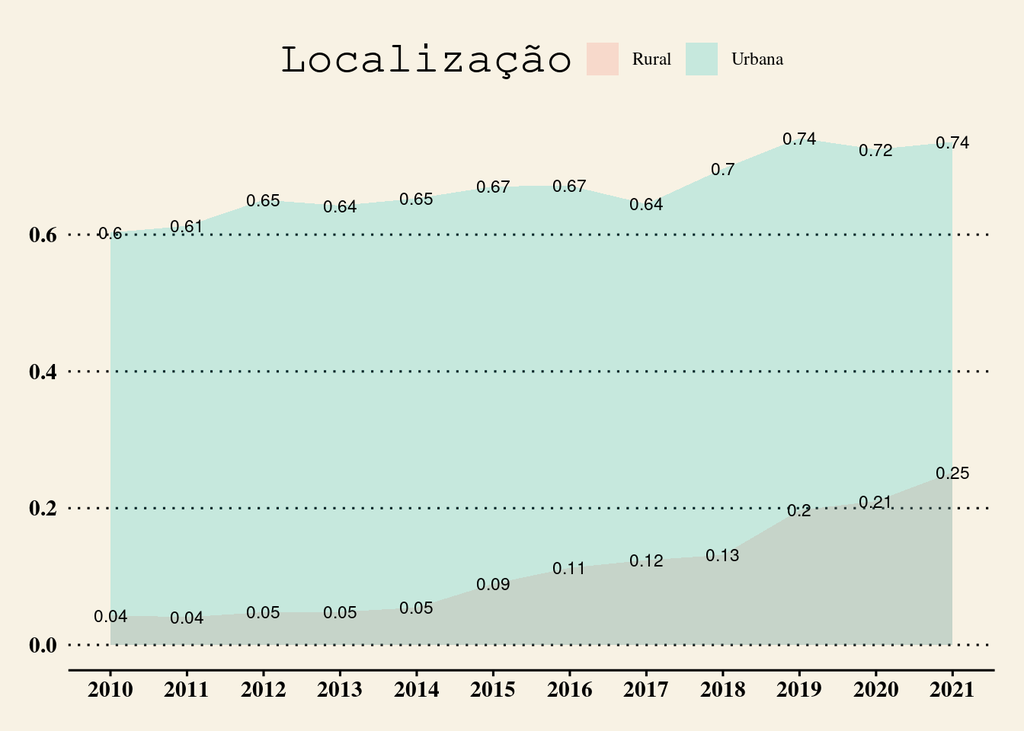